# Processing HMS Wildfire Smoke Data

#### Workflow

To perform this analysis we’ll be combining population data with wildfire smoke data (available daily) in order to approximate where, and how many people on the ground might have been exposed. Finally we’ll consider some population characteristics to identify disparate burdens to vulnerable populations.

Let’s begin by loading some selected libraries that we’ll use in this workshop. There are three included here:

1. [simple features](https://cran.r-project.org/web/packages/sf/index.html) for preforming spatial operations
   - *[This is a good resource](https://geocompr.robinlovelace.net/) for performing spatial operations in R*
2. [tidyverse](https://www.tidyverse.org/) partly out of habit, but ever useful for wrangling and visualizing data
   - *I also highly recommend [the accompanying book](https://r4ds.had.co.nz/)*
3. [data table](https://cran.r-project.org/web/packages/data.table/index.html) for speeding up the process of querying and manipulating large data sets
   - *This is a good [series of introductory vignettes](https://cran.r-project.org/web/packages/data.table/vignettes/datatable-intro.html) to the package*

```r
# install.packages(c("sf","tidyverse","date.table"))
library(sf)
library(tidyverse)
library(data.table)
```

#### Population Data

To know where people live and how many live there, we’ll need the population data for our state. For this we’ll use the [US Census state population centers](https://www.census.gov/geo/reference/centersofpop.html) - these are population-weight centers to each tract in the state. For California we use the state FIPS code ‘06’, you can change the code at the end of the URL below to use your state, and we’ll define it explicitly so we can call on it later. We’ll create the URL on the fly using the `paste0` function. Note: `fread` is the default reader from the `data.table` package and it allows us to read in this text file directly from a url.

```r
stateFIPs <- "06"
TRurl <- paste0("https://www2.census.gov/geo/docs/reference/cenpop2010/tract/CenPop2010_Mean_TR",stateFIPs,".txt")
TRcenters <- fread(TRurl)
```

Let’s take a look at the data

[output not shown]

```r
TRcenters
```

| STATEFP | COUNTYFP | TRACTCE | POPULATION | LATITUDE | LONGITUDE |
| --- | --- | --- | --- | --- | --- |
| 6 | 1 | 400100 | 2937 | 37.85942 | -122.2304 |
| 6 | 1 | 400200 | 1974 | 37.84829 | -122.2495 |
| 6 | 1 | 400300 | 4865 | 37.84027 | -122.2544 |
| 6 | 1 | 400400 | 3703 | 37.84845 | -122.2573 |
| 6 | 1 | 400500 | 3517 | 37.84894 | -122.2647 |
| 6 | 1 | 400600 | 1571 | 37.84223 | -122.2649 |
| 6 | 1 | 400700 | 4206 | 37.84172 | -122.2721 |
| 6 | 1 | 400800 | 3594 | 37.84539 | -122.2831 |
| 6 | 1 | 400900 | 2302 | 37.83928 | -122.2803 |
| 6 | 1 | 401000 | 5678 | 37.83126 | -122.2722 |

[output cut: 990 more lines]

Note that when reading in the data R automatically translated the FIPS codes to numbers and leading zeros were dropped

```r
class(TRcenters$STATEFP)
```

```
[1] "integer"
```

Alternatively we may wish to read in the geography FIPS as characters and combine them into a single string to more easily match them up with other data later. We’ll do this by defining the class of the columns as character using `colClasses` within the `fread` function. Then combining those fields without separators, using `paste0`. The `%>%` operator is used with the tidyverse for piping commands, and `mutate` appends the dataset with new variables that we define - in this case a long identifier for the tract called *GEOID*.

```r
TRcentersAlt <- fread(TRurl,
                      colClasses = c("character",
                                     "character",
                                     "character",
                                     "integer",
                                     "double",
                                     "double")) %>%
                mutate(GEOID = paste0(STATEFP, COUNTYFP, TRACTCE))
```

Let’s see how that looks

```r
TRcentersAlt
```

| STATEFP | COUNTYFP | TRACTCE | POPULATION | LATITUDE | LONGITUDE | GEOID |
| --- | --- | --- | --- | --- | --- | --- |
| 06 | 001 | 400100 | 2937 | 37.85942 | -122.2304 | 06001400100 |
| 06 | 001 | 400200 | 1974 | 37.84829 | -122.2495 | 06001400200 |
| 06 | 001 | 400300 | 4865 | 37.84027 | -122.2544 | 06001400300 |
| 06 | 001 | 400400 | 3703 | 37.84845 | -122.2573 | 06001400400 |
| 06 | 001 | 400500 | 3517 | 37.84894 | -122.2647 | 06001400500 |
| 06 | 001 | 400600 | 1571 | 37.84223 | -122.2649 | 06001400600 |
| 06 | 001 | 400700 | 4206 | 37.84172 | -122.2721 | 06001400700 |
| 06 | 001 | 400800 | 3594 | 37.84539 | -122.2831 | 06001400800 |
| 06 | 001 | 400900 | 2302 | 37.83928 | -122.2803 | 06001400900 |
| 06 | 001 | 401000 | 5678 | 37.83126 | -122.2722 | 06001401000 |

[output cut: 990 more lines]

```r
class(TRcentersAlt$STATEFP)
```

```
[1] "character"
```

Now we have a table of tract info, but we need it to be a spatial object if we are going to be able to combine it with smoke information. We use the `sf` package for this. We’ll use the Lat and Lon field already in the data and assign it the [Coordinate Reference System](https://mgimond.github.io/Spatial/coordinate-systems-in-r.html) (CRS) corresponding to [WGS84](http://spatialreference.org/ref/epsg/wgs-84/). Finally, we can plot the points and show population to verify that everything worked.

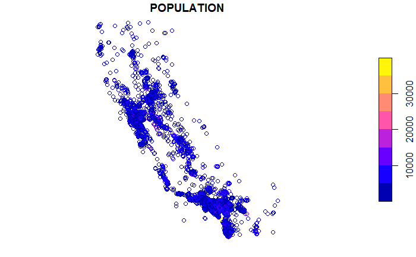

```r
TRcentersSP <- st_as_sf(TRcenters,
                        coords = c("LONGITUDE", "LATITUDE"),
                        crs = 4326)

plot(TRcentersSP["POPULATION"])
```

#### Wildfire Smoke Data

There are many potential sources for such data including monitor data, modeled data, and satellite (remotely sensed) data. For this exercise we will be looking at data from the National Oceanic and Atmospheric Administration’s Office of Satellite and Product Operations. Specifically, [NOAA’s Hazard Mapping System](https://www.ospo.noaa.gov/Products/land/hms.html) (HMS) Smoke Product.

- The initial HMS product for the current day is created and updated by a satellite analyst roughly between 8am and 10am Eastern Time. After 10am, the analysis is fine-tuned as time permits as additional satellite data becomes available. Areas of smoke are analyzed and added to the analysis during daylight hours as visible satellite imagery becomes available. The product is finalized and ‘completed’ for the archive the following morning - generally by around 800am.
- The fire sizes depicted in the product are primarily determined by the field of view of the satellite instrument, or the resolution of the analysis tool. They should not be used to estimate specific fire perimeters.
- The ability to detect fires and smoke can be compromised by many factors, including cloud cover, tree canopy, terrain, the size of the fire or smoke plume, the time of the day, etc. The satellite sensors used to detect fires are sensitive to heat sources and reflected sunlight. Analysts do their best to distinguish between fires and other heat sources or highly reflective surfaces, such as factories, mines, gas flares, solar panels, clouds, etc. but some false detects do get included in the analysis.

##### Technical Documentation of the HMS Products

- Use of multiple satellite sensors in NOAA’s operational near real-time fire and smoke detection and characterization program
- [Description and Verification of the NOAA Smoke Forecasting System: The 2007 Fire Season](https://journals.ametsoc.org/doi/pdf/10.1175/2008WAF2222165.1)

Here is a recent paper looking at the 2015 wildfire season in California which found * [Cardiovascular and Cerebrovascular Emergency Department Visits Associated With Wildfire Smoke Exposure in California in 2015](https://www.ncbi.nlm.nih.gov/pmc/articles/PMC6015400/pdf/JAH3-7-e007492.pdf)

Let’s first look at the recent (6 month) archive of HMS data available to download. It can be found here https://satepsanone.nesdis.noaa.gov/pub/FIRE/HMS/GIS/ARCHIVE/. You can see that the first date for which smoke data are available is in July 2018. There were several large fires in California this summer and fall and we’ll be able to examine them with this 6 month archive (keep in mind if accessing this exercise after the Feb 1st ISDS Workshop the available dates will be different).

When looking at the archive, you can see that files for each day are in the ESRI shapefile format, where each day’s spatial data consists of 3 files. In this chunk we’ll download the files (*.dbf*,*.shp*, *.shx*) and read them in as a single spatial object. We use the base function `substr` to separate the full ‘day’ into parts that we may want to use later. Finally, we’ll look at the fields in the data and produce a simple plot of it.

```r
HMSday <- 20180801 # define the day in the format it appears in the

year <- substr(HMSday, 1,4)
month <- substr(HMSday, 5,6)
day <- substr(HMSday, 7,8)

directory <- tempdir() # create a temporary directory to save the files as they're downloaded.

setwd(directory) # set the working directory to the temp directory we just created
```

```r
shpFiles <- list(paste0("http://satepsanone.nesdis.noaa.gov/pub/FIRE/HMS/GIS/ARCHIVE/hms_smoke",HMSday,".dbf"),
                 paste0("http://satepsanone.nesdis.noaa.gov/pub/FIRE/HMS/GIS/ARCHIVE/hms_smoke",HMSday,".shp"),
                 paste0("http://satepsanone.nesdis.noaa.gov/pub/FIRE/HMS/GIS/ARCHIVE/hms_smoke",HMSday,".shx"))

shpNames <- list("HMSGIS.dbf","HMSGIS.shp","HMSGIS.shx")

GISfiles <- mapply(download.file, # the function to execute
                   shpFiles, # a list of the urls to download
                   shpNames, # a list of the names of the destinations for the downloaded files
                   MoreArgs = list(method = "auto", mode = "wb")) # additional arguments for download.file function
```

```r
Smk <- st_read(dsn = "HMSGIS.shp") %>%  st_set_crs(4326) # read in the shapefile and
Smk
```

[output not shown]

There are 5 fields in the shapefile. *Density* is the field that contains the information about the concentration of the smoke observed. We’ll use that to take a preliminary look at the data. Before we plot it, we’ll reassign the values the HMS uses for *Density* to labels that make more sense for us.

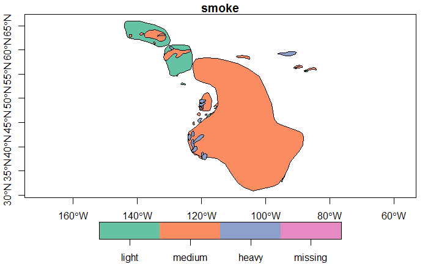

```r
Smk <- Smk %>%
  mutate(year = substr(HMSday, 1,4),
        month = substr(HMSday, 5,6),
        day = substr(HMSday, 7,8),
        date = paste0(year, month, day),
        smoke = factor(ifelse(Density %in% c(5, "5.000"), "light",
                             ifelse(Density %in% c(27, "27.000") ,"heavy",
                                    ifelse(Density %in% c(16, "16.000"), "medium", "missing"))),
                levels=c("light","medium","heavy","missing"))
         )

 plot(Smk["smoke"],
      axes = TRUE, # include axes labels in the plot
      key.pos = 1) # place legend at the bottom
```

```r
# install.packages("lwgeom")
library(lwgeom)

SmkTractDayInt <- st_intersection(st_make_valid(Smk),
                                  TRcentersSP) %>%
                        select(date,
                               year,
                               month,
                               day,
                               smoke,
                               STATEFP,
                               COUNTYFP,
                               TRACTCE,
                               POPULATION)
```

```r
SmkTractDayInt
```

[output not shown]

In examining the result we can see that a single tract from our population centers data can appear in the result multiple times, either for the same smoke level or for different smoke categories. This is because plumes in the HMS data can be stored as separate shapes, depending on the density of the smoke and the time/satellite from which it was derived. Conversely, some tracts do not appear in the result at all. We’ll deal with that in a moment. For now, we’ll make the decision here to consider an intersection with a plume to be an exposure for that tract and day. This will help to simplify the data and give us one observation for each tract-day-smoke combination in our result.

```r
st_geometry(SmkTractDayInt) <- NULL # remove the spatial information for the moment and if we want to work with it we can comment this line out

singleDay <- SmkTractDayInt  %>%
                mutate(yn = 1) %>% # since every observataion in our result is an instance of smoke with people, we'll give them all a value of 1
                group_by(date,
                         year,
                         month,
                         day,
                         smoke,
                         STATEFP,
                         COUNTYFP,
                         TRACTCE,
                         POPULATION) %>% # then we'll group by these variables
                summarise(yn = mean(yn)) %>% # and our yes/no marker will be averaged for instances of common smoke categories
                spread(key = smoke,value = yn)  # lastly, let's restructure the data to a wider format, where each smoke category has its own column
                                                # this is not exactly tidy-compliant, but we'll be using this soon

unlink(paste0(tempdir(),'/*'))     # clear temp folder
```

Now we have a dataset for a single day and state, where we could quickly compute the number of people under different smoke categories on a single day.

```r
sum(filter(singleDay, heavy == 1)$POPULATION)  # here is that quick calculation using the tidyr notation
```

```
[1] 435066
```

```r
as.data.table(singleDay)[heavy ==1, sum(POPULATION)] # here is that quick calculation using the data.table notation
```

```
[1] 435066
```

Alternatively, we may want to look at which places have the most people exposed, or view all of the tracts under heavy smoke on this day.

```r
filter(singleDay, heavy ==1) %>% arrange(POPULATION)
```

| date | year | month | day | STATEFP | COUNTYFP | TRACTCE | POPULATION | medium | heavy |
| --- | --- | --- | --- | --- | --- | --- | --- | --- | --- |
| 20180801 | 2018 | 08 | 01 | 6 | 3 | 10000 | 1175 | 1 | 1 |
| 20180801 | 2018 | 08 | 01 | 6 | 15 | 203 | 1373 | 1 | 1 |
| 20180801 | 2018 | 08 | 01 | 6 | 89 | 10603 | 1394 | 1 | 1 |
| 20180801 | 2018 | 08 | 01 | 6 | 93 | 1200 | 1409 | 1 | 1 |
| 20180801 | 2018 | 08 | 01 | 6 | 89 | 12500 | 1477 | 1 | 1 |
| 20180801 | 2018 | 08 | 01 | 6 | 21 | 10502 | 1564 | 1 | 1 |
| 20180801 | 2018 | 08 | 01 | 6 | 89 | 11001 | 1668 | 1 | 1 |
| 20180801 | 2018 | 08 | 01 | 6 | 7 | 401 | 1771 | 1 | 1 |
| 20180801 | 2018 | 08 | 01 | 6 | 43 | 400 | 1802 | 1 | 1 |
| 20180801 | 2018 | 08 | 01 | 6 | 49 | 200 | 1910 | 1 | 1 |

[output cut: 95 more lines]

```r
NA
```

Wow, a lot of different counties in California had thousands of people exposed on this day.

Recall that when we intersected the tract centroids and the smoke layer we lost tracts with no smoke on that day. It may also be useful to have these, if to only make it easier to see the entire state and population centers when mapping. But we may also want to quantify the percent of the total state or county population exposed. To do this we’d like for the result of our intersection to contain some information for every combination of date-tract-smoke.

```r
singleDayFull <- left_join(TRcenters, singleDay) %>%
                replace_na(list(date = HMSday,
                                year = substr(HMSday, 1,4),
                                month = substr(HMSday, 5,6),
                                day = substr(HMSday, 7,8),
                                light = 0,
                                medium = 0,
                                heavy = 0))
```

Now we have a table of the full list of our state’s tracts, the number of people in that tract, and the smoke level they experienced on that day. This is all well and good, but we’d like to make use of computational power to iterate and look at an episode or entire fire season. We already have the commands that we need, we only have to put them into a function that we can apply to several dates or states. The script in this function is just copied (and adapted slightly) from the chunks above.

```r
processHMSday <- function(HMSday){

    year <- substr(HMSday, 1,4)
    month <- substr(HMSday, 5,6)
    day <- substr(HMSday, 7,8)

    directory <- tempdir() # create a temporary directory to save the files as they're downloaded.

    setwd(directory) # set the working directory to the temp directory we just created

    shpFiles <- list(paste0("http://satepsanone.nesdis.noaa.gov/pub/FIRE/HMS/GIS/ARCHIVE/hms_smoke",HMSday,".dbf"),
                     paste0("http://satepsanone.nesdis.noaa.gov/pub/FIRE/HMS/GIS/ARCHIVE/hms_smoke",HMSday,".shp"),
                     paste0("http://satepsanone.nesdis.noaa.gov/pub/FIRE/HMS/GIS/ARCHIVE/hms_smoke",HMSday,".shx"))

    shpNames <- list("HMSGIS.dbf","HMSGIS.shp","HMSGIS.shx")

    GISfiles <- mapply(download.file, # the function to execute
                       shpFiles, # a list of the urls to download
                       shpNames, # a list of the names of the destinations for the downloaded files
                       MoreArgs = list(method = "auto", mode = "wb")) # additional arguments for download.file function

    Smk <- st_read(dsn = "HMSGIS.shp") %>%
      st_set_crs(4326) %>%
      mutate(year = substr(HMSday, 1,4),
        month = substr(HMSday, 5,6),
        day = substr(HMSday, 7,8),
        date = paste0(year, month, day),
        smoke = factor(ifelse(Density %in% c(5, "5.000"), "light",
                             ifelse(Density %in% c(27, "27.000") ,"heavy",
                                    ifelse(Density %in% c(16, "16.000"), "medium", "missing"))),
                levels=c("light","medium","heavy","missing")))

    SmkTractDayInt <- st_intersection(st_make_valid(Smk),
                                      TRcentersSP) %>%
                      select(date,
                             year,
                             month,
                             day,
                             smoke,
                             STATEFP,
                             COUNTYFP,
                             TRACTCE,
                             POPULATION) %>%
                    mutate(yn = 1) %>%
                    group_by(date,
                             year,
                             month,
                             day,
                             smoke,
                             STATEFP,
                             COUNTYFP,
                             TRACTCE,
                             POPULATION) %>%
                    summarise(yn = mean(yn)) %>%
                    spread(key = smoke,value = yn)

    st_geometry(SmkTractDayInt) <- NULL

    singleFull <- left_join(TRcenters, SmkTractDayInt) %>%
                        replace_na(list(date = HMSday,
                                        year = substr(HMSday, 1,4),
                                        month = substr(HMSday, 5,6),
                                        day = substr(HMSday, 7,8),
                                        light = 0,
                                        medium = 0,
                                        heavy = 0))

    unlink(paste0(tempdir(),'/*'))

    return(singleFull)

}
```

From the original tract population centers used earlier we have the total (2010) populations in each tract that we can use to produce estimates of the number of people exposed to heavy wildfire smoke. It may also be useful to understand the vulnerable populations that may be particularly impacted in a single event. For this we can dynamically obtain this data on the fly using the [American Community Survey API](https://www.census.gov/data/developers/data-sets/acs-5year.2016.html) for 2016. You can see the full list of 2016 ACS variables available through the API here https://api.census.gov/data/2016/acs/acs5/variables.html.

Recall that [this study of the 2015 California Wildfire Season](https://www.ncbi.nlm.nih.gov/pmc/articles/PMC6015400/pdf/JAH3-7-e007492.pdf) found significantly elevated risk of stroke and heart attack for those over 65 one day after exposure to heavy wildfire smoke (using HMS). Let’s begin by grabbing this data from ACS. Notice that a new package is needed to read in the data from the ACS’s API in JSON format.

```r
# install.packages("jsonlite")
library(jsonlite)

variable <- "B09020_001E" # this is a placeholde for the ACS varibale we'll read in, t in this case population over 65
# "B17021_016E" # in poverty and living alone


# first read in the data from the ACS and store as a data frome
#examining the data will show that the first row is the names of the data
elderly <-
    as.data.frame(fromJSON(
      paste0("https://api.census.gov/data/2016/acs/acs5?get=NAME,",variable,"&for=tract:*&in=state:",stateFIPs,"%20county:*"
      ), flatten = T
    ))

# elderlyName <- fromJSON(paste0("https://api.census.gov/data/2016/acs/acs5/variables/",variable,".json"), flatten = T)$label

# here we can elimiate the uneccessary first row and column AND...
# change the name and type of the variables to match our table of smoke exposures
elderly <- elderly[-1,-1] %>% mutate(estimate = as.integer(as.character(V2)),
                               STATEFP = as.integer(as.character(V3)),
                               COUNTYFP = as.integer(as.character(V4)),
                               TRACTCE = as.integer(as.character(V5))) %>%
                        select(STATEFP, COUNTYFP, TRACTCE, estimate)

elderly
```

| STATEFP | COUNTYFP | TRACTCE | estimate |
| --- | --- | --- | --- |
| 6 | 1 | 400100 | 718 |
| 6 | 1 | 400200 | 415 |
| 6 | 1 | 400300 | 712 |
| 6 | 1 | 400400 | 511 |
| 6 | 1 | 400500 | 345 |
| 6 | 1 | 400600 | 174 |
| 6 | 1 | 400700 | 602 |
| 6 | 1 | 400800 | 484 |
| 6 | 1 | 400900 | 223 |
| 6 | 1 | 401000 | 482 |

[output cut: 990 more lines]

```r
NA
```

Next we’ll combine the smoke and vulnerable population data we just grabbed from the ACS. And begin to visualize them.

```r
elderlySmoke <- merge(campFire, elderly)
```

[output not shown]

To begin visualizing the data, let’s first produce a timeline of the number of people exposed.

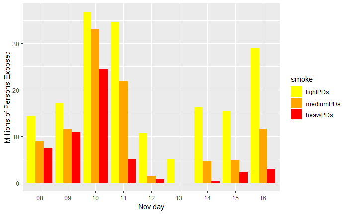

```r
elderlySmoke %>%
  group_by(day) %>%
  summarise(lightPDs = sum(light*POPULATION, na.rm = T),
            mediumPDs = sum(medium*POPULATION, na.rm = T),
            heavyPDs = sum(heavy*POPULATION, na.rm = T)
  ) %>%
  gather(lightPDs, mediumPDs, heavyPDs, key = smoke, value = PersonDays) %>%
  mutate(smoke = factor(x = smoke, levels = c("lightPDs", "mediumPDs", "heavyPDs"))) %>%
       ggplot(aes(
         x = day,
         y = PersonDays/1000000,
         fill = smoke
       )) +
       geom_bar(stat="identity", position="dodge") +
       scale_fill_manual(values = c("yellow","orange","red")) +
       ylab("Millions of Persons Exposed") +
       xlab("Nov day")
```

```r
NA
NA
```